# Analysis of RNA-seq data in R

Module Coordinator Mark Dunning

# Learning outcomes

- Construction and interpretation of common visualisations for RNA-seq
  - scatter plots
  - volcano plots
  - heatmaps
- Identifying enriched and over-represented pathways

We can now have a list of genes ordered according to their evidence for being differentially-expressed. You should have saved a `results_TGF_vs_CTR_annotated.rds` object in the previous session.

```r
library(DESeq2)
results_tgf  <- readRDS("Robjects/results_TGF_vs_CTR_annotated.rds")
```

If you did not save the results from comparing `TGF` to `CTR`, you can use an object from the course materials

```r
library(DESeq2)
results_tgf <- readRDS("Robjects/results_TGF_vs_CTR_annotated_BACKUP.rds")
```

# Further Visualisation

Now we have annotated our results, we can start to explore some common visualisation techniques. In the process we will hope to gain more insights into our results

## The Volcano Plot

A common plot for displaying the results of a differential expression analysis is a *volcano plot*. It is a *scatter plot* that shows statistical significance and the magnitude of difference between conditions. They are used to identify which genes are the most significant and are also changing by the most amount.

The data we need for the plot is contained in our `results_tgf` data frame. This basic plot displays a point for every gene, but does not take advantage of some of the other columns in the data frame.

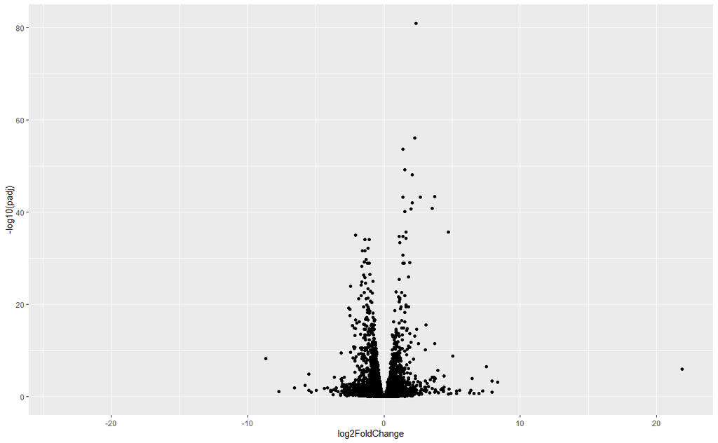

```r
library(ggplot2)
results_tgf %>%
  ggplot(aes(x = log2FoldChange, y = -log10(padj))) + geom_point()
```

One modification is to colour the points according to whether each gene is significant in the analysis. The indicator of significance can be a new column in the data frame that we create on-the-fly using the pipe operator.

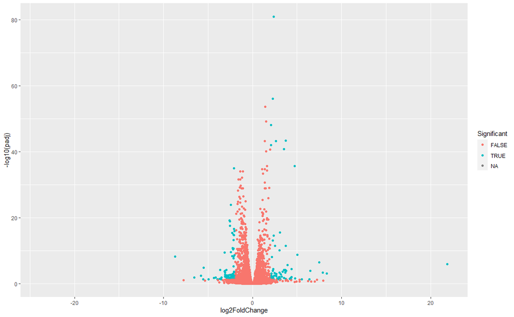

```r
results_tgf %>%
  mutate(Significant = padj < 0.05 & abs(log2FoldChange) > 2) %>%
  ggplot(aes(x = log2FoldChange, y = -log10(padj), col=Significant)) + geom_point()
```

We can also add the gene names to the plot. This should be straightforward as ggplot2 has a `label` aesthetic that can be mapped to columns in a data frame. The `geom_text` plot will then display the labels. However, the following plot is a bit crowded.

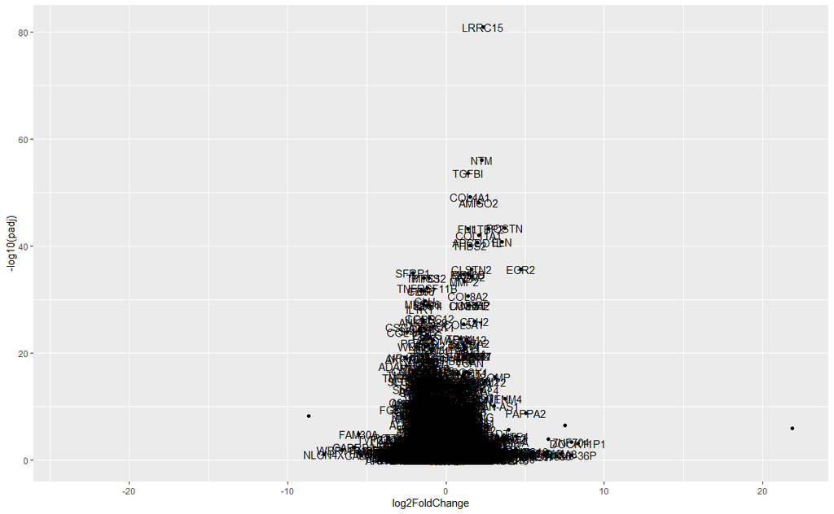

```r
## Not a good idea to run this!!
results_tgf %>%
  ggplot(aes(x = log2FoldChange, y = -log10(padj), label=SYMBOL)) + geom_point() + geom_text()
```

The problem here is that ggplot2 is trying to label every point with a name; not quite what we want. The trick is to create a label that is blank for most genes and only labels the points we are interested in. The `ifelse` function in R is a convenient way to set the entries in a vector based on a *logical* expression. In this case, make the values in `Label` the same as the gene symbol if the gene is in our list of “top genes”. Otherwise, points get labeled with a blank string `""`.

For clarity, we also make the points slightly transparent and use a different colour for the text.

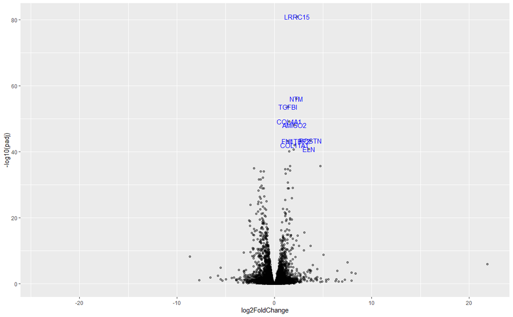

```r
N <- 10
top_genes <- results_tgf$ENSEMBL[1:N]
results_tgf %>%
  mutate(Label = ifelse(ENSEMBL %in% top_genes, SYMBOL, "")) %>%
  ggplot(aes(x = log2FoldChange, y = -log10(padj), label=Label)) + geom_point(alpha=0.4) + geom_text(col="blue")
```

Finally, a slightly better positioning of text is given by the `ggrepel` package.

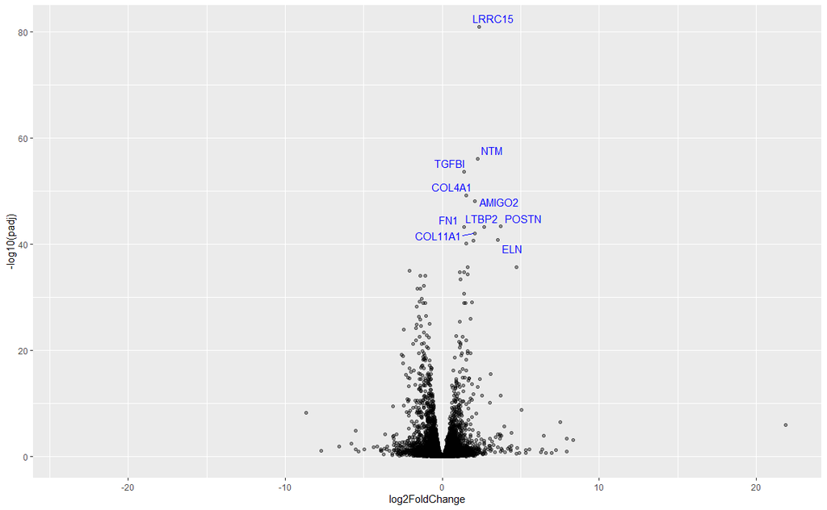

```r
if(!require(ggrepel)) install.packages("ggrepel")

results_tgf %>%
  mutate(Label = ifelse(ENSEMBL %in% top_genes, SYMBOL, "")) %>%
  ggplot(aes(x = log2FoldChange, y = -log10(padj), label=Label)) + geom_point(alpha=0.4) + geom_text_repel(col="blue")
```

The labeling of genes on the plot is not restricted to the most significant genes. We could use a similar approach to label any set of genes that we are interested in.

For instance, we could hypothesise that Extra-Cellular Matrix (ECM) genes play are important for the transformation in cells treated with TGF. We could use the volcano plot to demonstrate whether genes belonging to this pathway show evidence for being differentially-expressed

# Exercise

- Which genes belong to the ECM pathway (GO:0030198)? Get their `ENSEMBL` IDs using the `AnnotationDbi::select` function
- Produce a volcano plot (as above) with points coloured according to whether a gene belongs to the ECM pathway
  - there will be too many genes in the pathway to be able to label their names

## Heatmaps

You may have already seen the use of a heatmap as a quality assessment tool to visualise the relationship between samples in an experiment. Another common use-case for such a plot is to visualise the results of a differential expression analysis. Although `ggplot2` has a `geom_tile` function to make heatmaps, specialised packages such as `pheatmaps` offer more functionality such as clustering the samples.

The counts we are visualising are the *variance-stablised* counts, which are more appropriate for visualisation.

Here we will take the top 10 genes from the differential expression analysis and produce a heatmap with the `pheatmap` package. We can take advantage of the fact the our counts table contains Ensembl gene names in the rows. Standard subset operations in R can then be used.

The default colour palette goes from low expression in blue to high expression in red, which is a good alternative to the traditional red/green heatmaps which are not suitable for those with forms of colour-blindness.

```r
dds <- readRDS("Robjects/dds_BACKUP.rds")
```

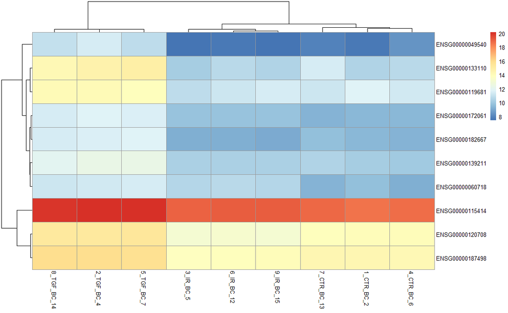

```r
# pheatmap is a specialised package to make heatmaps
library(pheatmap)
top_genes <- results_tgf$ENSEMBL[1:10]
vsd <- vst(dds)

# top_genes is a vector containing ENSEMBL names of the genes we want to see in the heatmap

pheatmap(assay(vsd)[top_genes,])
```

The heatmap is more informative if we add colours underneath the sample dendrogram to indicate which sample group each sample belongs to. This we can do by creating a data frame containing metadata for each of the samples in our dataset. With the `DESeq2` workflow we have already created such a data frame. We have to make sure the the rownames of the data frame are the same as the column names of the counts matrix.

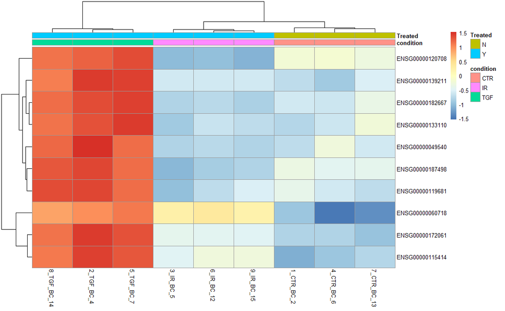

```r
sampleInfo <- as.data.frame(colData(dds)[,c("condition","Treated")])

pheatmap(assay(vsd)[top_genes,],
         annotation_col = sampleInfo,
         scale="row")
```

Any plot we create in RStudio can be saved as a png or pdf file. We use the `png` or `pdf` function to create a file for the plot to be saved into and run the rest of the code as normal. The plot does not get displayed in RStudio, but printed to the specified file.

```r
png("heatmap_top10_genes.png",width=800,height=800)
pheatmap(assay(vsd)[top_genes,],
         annotation_col = sampleInfo)
# dev.off()
```

There are many arguments to explore in `pheatmap`. For example, we might want to use a specific order to the rows and columns rather than using clustering. A useful option is to specific our own labels for the rows (genes). The default is to use the rownames of the count matrix. In our cases these are Ensembl IDs and not easy to interpret.

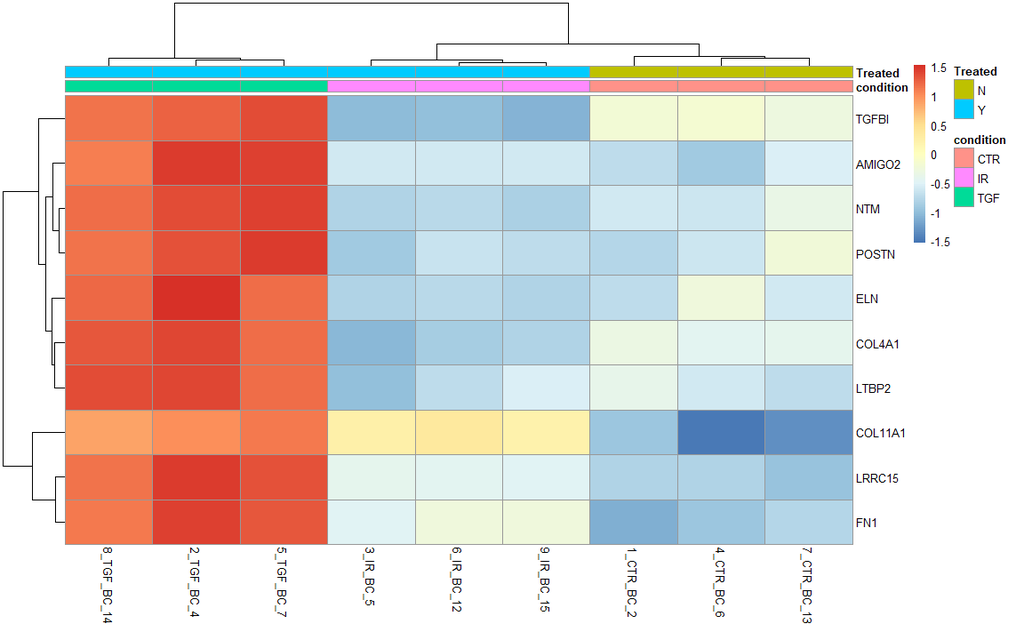

```r
gene_labels <- results_tgf$SYMBOL[1:N]

pheatmap(assay(vsd)[top_genes,],
         annotation_col = sampleInfo,
         labels_row = gene_labels,
         scale="row")
```

Given the nature of how the genes were selected for the heatmap, we shouldn’t be surprised by the good separation that it demonstrates.

Instead, an un-biased approach can be used where we choose genes based on their variability across the whole dataset. The variability of a gene can be calculated using the convenient `rowSds` function applied to the variance-stabilised counts in the `vsd` object. However, some genes have very low expression and were not tested by `DESeq2`. We can exclude these from the visualisation

```r
res_with_var <- mutate(results_tgf, GeneVar = rowSds(assay(vsd))) %>%
  filter(!is.na(padj))
```

# Exercise

- Produce a heatmap of the top 100 most-variable genes (as measure by their standard deviation across the dataset)
  - First, re-arrange the table `res_with_var` from above by decreasing `GeneVar`
  - Identify the `ENSEMBL` IDs for the first 100 rows. The `slice` function from `dplyr` might be useful here
  - Use these 100 IDs in the heatmap instead of the most significant genes that we used previously
  - you will need to use code something like this, where `genes_to_plot` is the ENSEMBL IDs that you identify

```r
pheatmap(assay(vsd)[genes_to_plot,],
         annotation_col = sampleInfo,
         scale="row")
```

# Pathways analysis

In this section we move towards discovering if our results are *biologically significant*. Are the genes that we have picked statistical flukes, or are there some commonalities.

There are two different approaches one might use, and we will cover the theory behind both.

## Threshold-based Gene Set Testing

For a particular pathway we need to calculate how many genes were identified as differentially-expressed and compare to *how many we would be expect by chance*. Or in other words, if we repeatedly generated a list of differentially-expressed genes at random how many genes from this pathway would be expect to see.

For the ECM pathway we can extract all genes as follows:-

```r
## The pull function from dplyr is used to extract a particular column
library(org.Hs.eg.db)
pathway_genes <- AnnotationDbi::select(org.Hs.eg.db,
                                       keys = "GO:0030198",
                                       keytype = "GO",
                                       columns="ENSEMBL") %>% pull(ENSEMBL)
```

We can then annotate each gene in our results according to whether it belongs to this pathway, and whether it is differentially-expressed.

```r
go_table <- mutate(results_tgf,
                   inPathway = ENSEMBL %in% pathway_genes,
                   isDE = padj < 0.05 & abs(log2FoldChange) > 1)
go_table
```

| ENSEMBL | baseMean | log2FoldChange | lfcSE | stat | pvalue | padj | SYMBOL | GENENAME | ENTREZID | inPathway | isDE |
| --- | --- | --- | --- | --- | --- | --- | --- | --- | --- | --- | --- |
| ENSG00000172061 | 1496.02360 | 2.3677544 | 0.12053491 | 19.643722 | 6.542235e-86 | 1.225361e-81 | LRRC15 | leucine rich repeat containing 15 | 131578 | FALSE | TRUE |
| ENSG00000182667 | 1394.43702 | 2.2742055 | 0.13836809 | 16.435910 | 1.058240e-60 | 9.910418e-57 | NTM | neurotrimin | 50863 | FALSE | TRUE |
| ENSG00000120708 | 21979.41299 | 1.4007396 | 0.08717418 | 16.068286 | 4.256974e-58 | 2.657771e-54 | TGFBI | transforming growth factor beta induced | 7045 | TRUE | TRUE |
| ENSG00000187498 | 31585.64079 | 1.5060704 | 0.09770908 | 15.413821 | 1.321598e-53 | 6.188384e-50 | COL4A1 | collagen type IV alpha 1 chain | 1282 | TRUE | TRUE |
| ENSG00000139211 | 2332.20548 | 2.0799087 | 0.13663368 | 15.222518 | 2.506932e-52 | 9.390966e-49 | AMIGO2 | adhesion molecule with Ig like domain 2 | 347902 | FALSE | TRUE |
| ENSG00000133110 | 9347.17926 | 3.7221265 | 0.25709026 | 14.477898 | 1.671309e-47 | 5.217271e-44 | POSTN | periostin | 10631 | TRUE | TRUE |
| ENSG00000119681 | 7159.35569 | 2.6489665 | 0.18319688 | 14.459670 | 2.178393e-47 | 5.828758e-44 | LTBP2 | latent transforming growth factor beta binding protein 2 | 4053 | FALSE | TRUE |
| ENSG00000115414 | 683624.26585 | 1.3814954 | 0.09566356 | 14.441187 | 2.848923e-47 | 6.670041e-44 | FN1 | fibronectin 1 | 2335 | TRUE | TRUE |
| ENSG00000060718 | 1521.83189 | 2.0858907 | 0.14639073 | 14.248789 | 4.561204e-46 | 9.492372e-43 | COL11A1 | collagen type XI alpha 1 chain | 1301 | TRUE | TRUE |
| ENSG00000049540 | 791.38498 | 3.5358715 | 0.25174087 | 14.045679 | 8.187951e-45 | 1.533603e-41 | ELN | elastin | 2006 | TRUE | TRUE |

[output cut: 990 more lines]

Cross-tabulating the two new columns gives a basis for a statistical test

```r
table(go_table$inPathway, go_table$isDE)
```

```
        FALSE  TRUE
  FALSE 30956   534
  TRUE    180    37
```

The Fisher’s exact test or chi-squared test (as seen here) can then be used

```r
chisq.test(table(go_table$inPathway, go_table$isDE))
```

```
    Pearson's Chi-squared test with Yates' continuity correction

data:  table(go_table$inPathway, go_table$isDE)
X-squared = 278.71, df = 1, p-value < 2.2e-16
```

In reality it would be impractical to test all possible pathways in this manner, so there are a number of Bioconductor packages that automate the process

### Analysis with clusterProfiler

`clusterProfiler` is a Bioconductor package for over-representation analysis. It’s main advantage is that it provides some nice visualisation methods.

The main function is `enrichGO` which requires the IDs of genes found to be differentially-expressed (`sigGenes`) and the IDs of *all* genes in the dataset (`universe`). It uses the `org.Hs.eg.db` package to map between gene names and biological pathways.

```r
library(clusterProfiler)
universe <- results_tgf %>% pull(ENSEMBL)
sigGenes <- results_tgf %>%
  filter(padj < 0.05, !is.na(ENSEMBL)) %>% pull(ENSEMBL)

enrich_go <- enrichGO(
  gene= sigGenes,
  OrgDb = org.Hs.eg.db,
  keyType = "ENSEMBL",
  ont = "BP",
  universe = universe,
  qvalueCutoff = 0.05,
  readable=TRUE
)
```

The result of `enrichGo` can be turned into a data frame for easier interpretation.

```r
enrich_go %>% data.frame
```

|  | ID | Description | GeneRatio | BgRatio | pvalue | p.adjust | qvalue | geneID | Count |
| --- | --- | --- | --- | --- | --- | --- | --- | --- | --- |
| GO:0030198 | GO:0030198 | extracellular matrix organization | 127/2004 | 392/18579 | 1.339040e-31 | 5.320880e-28 | 4.261229e-28 | TGFBI/COL4A1/POSTN/FN1/COL11A1/ELN/BGN/MMP2/TNFRSF11B/COL8A2…… | 127 |
| GO:0043062 | GO:0043062 | extracellular structure organization | 127/2004 | 393/18579 | 1.776291e-31 | 5.320880e-28 | 4.261229e-28 | TGFBI/COL4A1/POSTN/FN1/COL11A1/ELN/BGN/MMP2/TNFRSF11B/COL8A2…… | 127 |
| GO:0045229 | GO:0045229 | external encapsulating structure organization | 127/2004 | 395/18579 | 3.114400e-31 | 6.219457e-28 | 4.980855e-28 | TGFBI/COL4A1/POSTN/FN1/COL11A1/ELN/BGN/MMP2/TNFRSF11B/COL8A2…… | 127 |
| GO:0072001 | GO:0072001 | renal system development | 75/2004 | 288/18579 | 2.026574e-13 | 3.035301e-10 | 2.430822e-10 | COL4A1/SFRP1/KIF26B/PDGFD/WNT2B/SERPINB7/FBN1/AKR1B1/FSTL3/A…… | 75 |
| GO:0001655 | GO:0001655 | urogenital system development | 80/2004 | 320/18579 | 3.389641e-13 | 3.593653e-10 | 2.877978e-10 | COL4A1/SFRP1/KIF26B/PDGFD/WNT2B/SERPINB7/FBN1/AKR1B1/CYP7B1/…… | 80 |
| GO:0001503 | GO:0001503 | ossification | 93/2004 | 399/18579 | 3.599051e-13 | 3.593653e-10 | 2.877978e-10 | COL11A1/EGR2/SFRP1/MMP2/STC1/CSGALNACT1/ITGA11/VCAN/HGF/COMP…… | 93 |
| GO:0001822 | GO:0001822 | kidney development | 72/2004 | 280/18579 | 1.198723e-12 | 1.025935e-09 | 8.216208e-10 | SFRP1/KIF26B/PDGFD/WNT2B/SERPINB7/FBN1/AKR1B1/FSTL3/ACTA2/AD…… | 72 |
| GO:0001501 | GO:0001501 | skeletal system development | 103/2004 | 485/18579 | 8.730920e-12 | 6.538368e-09 | 5.236254e-09 | TGFBI/COL11A1/SFRP1/BGN/MMP2/TNFRSF11B/STC1/CSGALNACT1/WNT2B…… | 103 |
| GO:0007160 | GO:0007160 | cell-matrix adhesion | 60/2004 | 230/18579 | 4.780733e-11 | 3.182374e-08 | 2.548606e-08 | POSTN/FN1/SFRP1/CD36/NID2/ITGA11/FBLN5/VCAM1/RCC2/MMP14/GPM6…… | 60 |
| GO:0050673 | GO:0050673 | epithelial cell proliferation | 92/2004 | 428/18579 | 5.808148e-11 | 3.479662e-08 | 2.786688e-08 | SFRP1/FGF7/COL8A2/EREG/F3/CCN3/HGF/AREG/NR4A3/CYP7B1/SPARC/T…… | 92 |

[output cut: 683 more lines]

A dot plot can show us the most enriched pathways, and the size of each.

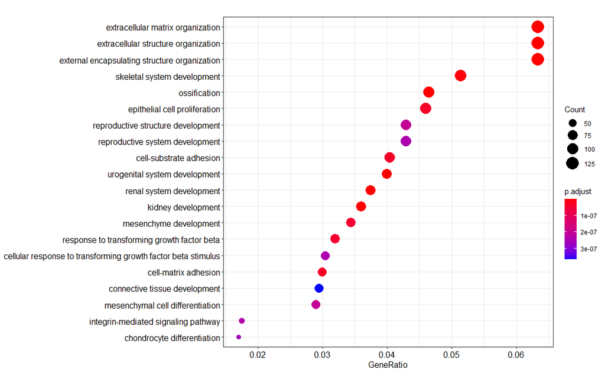

```r
dotplot(enrich_go,showCategory=20)
```

Relationships between the identified categories can be found using `emapplot`.

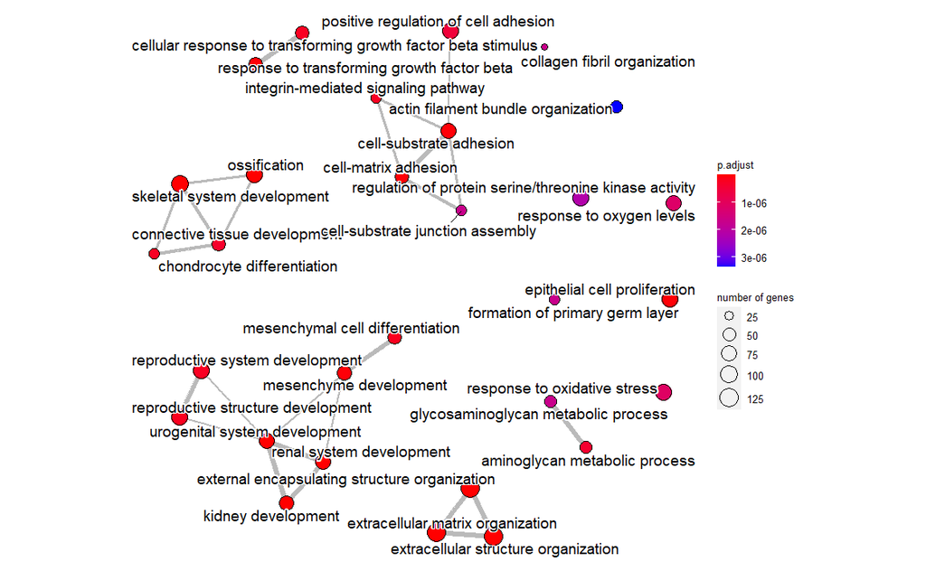

```r
enrich_go <- enrichplot::pairwise_termsim(enrich_go)
emapplot(enrich_go)
```

Overlaps between gene sets can also be visualised using an “Upset plot” - an alternative to a venn diagram.

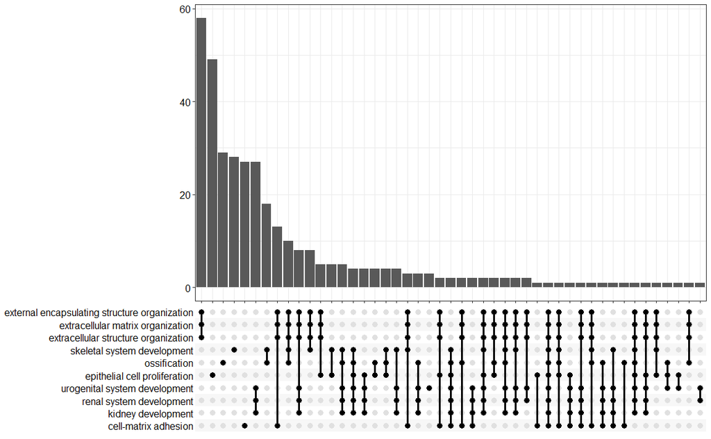

```r
enrichplot::upsetplot(enrich_go)
```

## Gene set enrichment analysis (GSEA)

An appealing feature of the **GSEA** method is that it does not require us to impose arbitrary cut-offs on the dataset to decide what is differentially-expressed or not. The steps in producing the input required for GSEA are i) retrieving the ranked statistics ii) naming each one according to a chosen identifier (`ENSEMBL` or `ENTREZID` for example).

The `clusterProfiler` package also includes an implementation of the GSEA algorithm, and the function works in much the same way as `enrichGO` from above.

```r
ranked_genes <- results_tgf %>%
  arrange(desc(stat)) %>%
  filter(!is.na(stat))

geneList <- pull(ranked_genes, stat)
names(geneList) <- pull(ranked_genes, ENSEMBL)

gse_GO  <- gseGO(geneList = geneList,
        OrgDb = org.Hs.eg.db,
        ont = "BP",keyType = "ENSEMBL")
```

```r
gse_GO %>% as.data.frame
```

|  | ID | Description | setSize | enrichmentScore | NES | pvalue | p.adjust | qvalues | rank | leading_edge | core_enrichment |
| --- | --- | --- | --- | --- | --- | --- | --- | --- | --- | --- | --- |
| GO:0002283 | GO:0002283 | neutrophil activation involved in immune response | 458 | -0.5030430 | -2.059465 | 1.000000e-10 | 1.030333e-07 | 7.280702e-08 | 4740 | tags=31%, list=11%, signal=28% | ENSG00000172322/ENSG00000168461/ENSG00000127481/ENSG00000102…… |
| GO:0002446 | GO:0002446 | neutrophil mediated immunity | 469 | -0.5107515 | -2.096267 | 1.000000e-10 | 1.030333e-07 | 7.280702e-08 | 4740 | tags=31%, list=11%, signal=28% | ENSG00000172322/ENSG00000168461/ENSG00000127481/ENSG00000102…… |
| GO:0006631 | GO:0006631 | fatty acid metabolic process | 368 | -0.4874772 | -1.959638 | 1.000000e-10 | 1.030333e-07 | 7.280702e-08 | 5418 | tags=31%, list=13%, signal=27% | ENSG00000105852/ENSG00000186529/ENSG00000110958/ENSG00000096…… |
| GO:0036230 | GO:0036230 | granulocyte activation | 473 | -0.5056012 | -2.076707 | 1.000000e-10 | 1.030333e-07 | 7.280702e-08 | 4740 | tags=31%, list=11%, signal=28% | ENSG00000172322/ENSG00000168461/ENSG00000127481/ENSG00000102…… |
| GO:0042119 | GO:0042119 | neutrophil activation | 468 | -0.5074208 | -2.080598 | 1.000000e-10 | 1.030333e-07 | 7.280702e-08 | 4740 | tags=31%, list=11%, signal=28% | ENSG00000172322/ENSG00000168461/ENSG00000127481/ENSG00000102…… |
| GO:0043312 | GO:0043312 | neutrophil degranulation | 455 | -0.5042359 | -2.063568 | 1.000000e-10 | 1.030333e-07 | 7.280702e-08 | 4740 | tags=31%, list=11%, signal=28% | ENSG00000172322/ENSG00000168461/ENSG00000127481/ENSG00000102…… |
| GO:0043062 | GO:0043062 | extracellular structure organization | 373 | 0.4545260 | 1.903138 | 1.436601e-10 | 1.268724e-07 | 8.965252e-08 | 3652 | tags=32%, list=9%, signal=29% | ENSG00000120708/ENSG00000187498/ENSG00000133110/ENSG00000115…… |
| GO:0045229 | GO:0045229 | external encapsulating structure organization | 375 | 0.4536388 | 1.898988 | 2.627272e-10 | 2.030224e-07 | 1.434629e-07 | 3652 | tags=31%, list=9%, signal=29% | ENSG00000120708/ENSG00000187498/ENSG00000133110/ENSG00000115…… |
| GO:0030198 | GO:0030198 | extracellular matrix organization | 372 | 0.4546903 | 1.903476 | 5.698735e-10 | 3.914398e-07 | 2.766052e-07 | 3652 | tags=32%, list=9%, signal=29% | ENSG00000120708/ENSG00000187498/ENSG00000133110/ENSG00000115…… |
| GO:0006956 | GO:0006956 | complement activation | 69 | -0.7016213 | -2.288295 | 1.983190e-09 | 1.226008e-06 | 8.663408e-07 | 1420 | tags=28%, list=3%, signal=27% | ENSG00000159403/ENSG00000106804/ENSG00000139178/ENSG00000184…… |

[output cut: 990 more lines]

An overview of the results can be provided by a “ridge plot”. This allows comparison of the test statistics for each of the top enriched pathways.

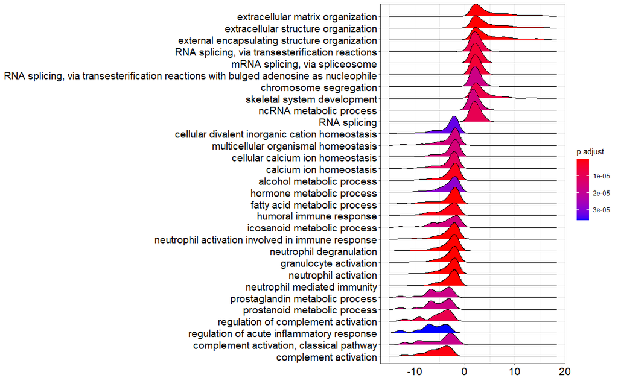

```r
ridgeplot(gse_GO)
```

An upset plot can still be produced, but this time the distribution of statistics for overlapping categories can be produced.

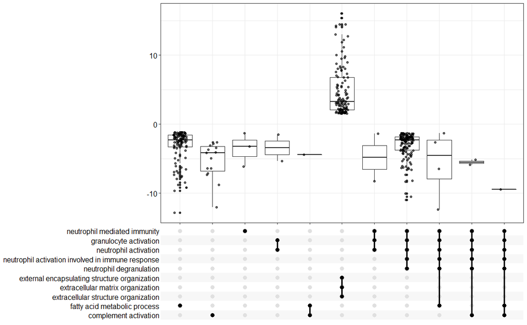

```r
enrichplot::upsetplot(gse_GO)
```

The results confirm that the ECM pathway has many differentially-expressed genes (more than we would expect by chance). Moreover, there is a tendancy for these genes to be up-regulated; as indicated by the high positive enrichment score. Another way to visualise the GSEA results, that is typically produced from the GSEA java app, is the so-called enrichment plot.

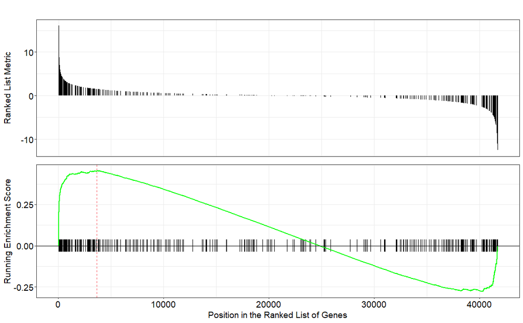

```r
gseaplot(gse_GO,geneSetID = "GO:0030198")
```

The enrichment plot for a gene set with a high negative enrichment score reveals a different pattern.

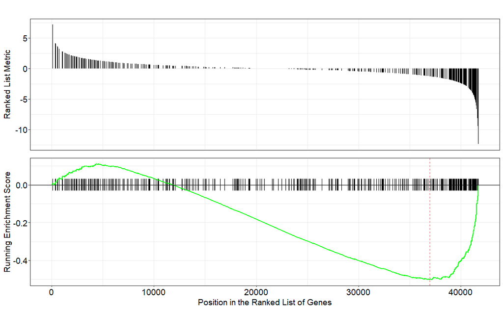

```r
gseaplot(gse_GO,geneSetID = "GO:0002283")
```

# Exercise

- In addition to enriched GO terms, `clusterProfiler` can also find enriched [KEGG](https://www.genome.jp/kegg/) terms using the `enrichKEGG` function. There are a couple of changes that are required from `enrichGO`
  - `ENTREZID` have to be used as the identifer type
  - the user must input an appropriate [organism code](https://www.genome.jp/kegg/catalog/org_list.html). The code for humans is `hsa`.
- Use the `enrichKEGG` function to identify enriched KEGG terms in the analysis.
- (Optional) If you have time, use the gseKEGG to perform GSEA using KEGG terms.

# Appendix: Annotation with the biomaRt resource

The Bioconductor package have the convenience of being able to make queries offline. However, they are only available for certain organisms. If your organism does not have an `org.XX.eg.db` package listed on the Bioconductor annotation page (http://bioconductor.org/packages/release/BiocViews.html#___AnnotationData), an alternative is to use biomaRt which provides an interface to the popular biomart annotation resource.

The first step is to find the name of a database that you want to connect to.

```r
library(biomaRt)
listMarts()
```

| biomart | version |
| --- | --- |
| ENSEMBL_MART_ENSEMBL | Ensembl Genes 104 |
| ENSEMBL_MART_MOUSE | Mouse strains 104 |
| ENSEMBL_MART_SNP | Ensembl Variation 104 |
| ENSEMBL_MART_FUNCGEN | Ensembl Regulation 104 |

```r
ensembl=useMart("ENSEMBL_MART_ENSEMBL")
# list the available datasets (species). Replace human with the name of your organism
listDatasets(ensembl) %>% filter(grepl("Human",description))
```

| dataset | description | version |
| --- | --- | --- |
| hsapiens_gene_ensembl | Human genes (GRCh38.p13) | GRCh38.p13 |

```r
ensembl = useDataset("hsapiens_gene_ensembl", mart=ensembl)
```

Queries to `biomaRt` are constructed in a similar way to the queries we performed with the `org.Hs.eg.db` package. Instead of `keys` we have `filters`, and instead of `columns` we have attributes. The list of acceptable values is much more comprehensive that for the `org.Hs.eg.db` package.

```r
listFilters(ensembl) %>%
    filter(grepl("ensembl",name))
```

| name | description |
| --- | --- |
| ensembl_gene_id | Gene stable ID(s) [e.g. ENSG00000000003] |
| ensembl_gene_id_version | Gene stable ID(s) with version [e.g. ENSG00000000003.15] |
| ensembl_transcript_id | Transcript stable ID(s) [e.g. ENST00000000233] |
| ensembl_transcript_id_version | Transcript stable ID(s) with version [e.g. ENST00000000233.10] |
| ensembl_peptide_id | Protein stable ID(s) [e.g. ENSP00000000233] |
| ensembl_peptide_id_version | Protein stable ID(s) with version [e.g. ENSP00000000233.5] |
| ensembl_exon_id | Exon ID(s) [e.g. ENSE00000000003] |

```r
listAttributes(ensembl) %>%
    filter(grepl("gene",name))
```

An advantage over the `org..` packages is that positional information can be retrieved

```r
attributeNames <- c('ensembl_gene_id', 'entrezgene_id', 'external_gene_name', "chromosome_name","start_position","end_position")

getBM(attributes = attributeNames,
      filters = "ensembl_gene_id",
      values=top_genes,
      mart=ensembl)
```

| ensembl_gene_id | entrezgene_id | external_gene_name | chromosome_name | start_position | end_position |
| --- | --- | --- | --- | --- | --- |
| ENSG00000049540 | 2006 | ELN | 7 | 74027789 | 74069907 |
| ENSG00000060718 | 1301 | COL11A1 | 1 | 102876467 | 103108872 |
| ENSG00000115414 | 2335 | FN1 | 2 | 215360440 | 215436073 |
| ENSG00000119681 | 4053 | LTBP2 | 14 | 74498183 | 74612378 |
| ENSG00000120708 | 7045 | TGFBI | 5 | 136028988 | 136063818 |
| ENSG00000133110 | 10631 | POSTN | 13 | 37562583 | 37598844 |
| ENSG00000139211 | 347902 | AMIGO2 | 12 | 47075707 | 47079959 |
| ENSG00000172061 | 131578 | LRRC15 | 3 | 194355249 | 194369743 |
| ENSG00000182667 | 50863 | NTM | 11 | 131370478 | 132336822 |
| ENSG00000187498 | 1282 | COL4A1 | 13 | 110148963 | 110307157 |